# RcmdrPlugin.aRnova: a Tutorial (in progress…)

Jessica Mange and Arnaud Travert

2025-05-06

## 1. Introduction

RcmdrPlugin.aRnova is a R Commander add-on for repeated-measures and mixed-design (‘split-plot’) analysis of variance (ANOVA). In essence it adds a new menu entry for repeated measures that allows to deal with up to three within-subject factors and optionally with one or several between-subject factors. Besides, it also provides supplementary options and outputs to the existing `One Way ANOVA` and `Multi Way ANOVA` entries, such as the choice of type of sum of squares (II or III), the calculation of effect sizes, or multiway ANOVA post-hoc analysis.

This tutorial (not finished yet…) aims to illustrate typical use of this plugin by replicating ANOVAs described in particular in John Fox’ *R and S-plus Companion to Applied Regession* (SAGE Publications Inc. 2002). While all steps are illustrated in the following, the user is expected to have minimal proficiency in using Rcmdr.

## 2. Installation and loading of RcmdrPlugin.aRnova

The aRnova plugin can be downloaded and installed using:

```
> install.packages("RcmdrPlugin.aRnova")
```

To load the package the fastest way is to use the following R command line which causes the package to load Rcmdr *simultaneously with* the aRnova plugin:

```
> library("RcmdrPlugin.aRnova")
```

Note that if aRnova has just been installed, restart a new R session before launching this command (else the following error may occur: `Error : .onAttach failed in attachNamespace() for [....]`).

Alternatively, after loading Rcmdr *without* the aRnova plugin using:

```
> library("Rcmdr")
```

The aRnova package can then be loaded using the `Tools` > `Load Packages...` menu entry in Rcmdr. The user is then asked to restart Rcmdr so that the Plug-in is available.

It can be verified that aRnova has been effectively loaded by checking that the supplementary entry `Repeated measures ANOVA...` has been added in the `Statistics` > `Means` Rcmr menu.

[figure not shown]

## 3. One-way ANOVA

## 4. Multi Way ANOVA

The multiway ANOVA is illustrated here using the data form Moore and Krupat (1971) on conformity. The dataset can be found in the *car* package (`Moore.rda`) and in the present package for convenience. The treatment below reproduces the treatmant of section 4.3 of John Fox *R and S-plus Companion to Applied Regession* (SAGE Publications, 2002).

[figure not shown]

### 4.1. levels reordering

The replication of this analysis starts by re-ordering the levels of `fcategory` in the order low < medium < high (the default ordering is the alphabetical order). This reordering is essentially for graphical purpose. This can be done in Rcmdr by using the menu entry `Data` > `Manage variables in the active dataset` > `Reorder factor levels...` as illustrated in Figure 2.

[figure not shown]

After re-ordering, the means of all combinations of factors (*cells*) can be plot using the menu entry `Graphs` > `Plot of means...` which yields the dialog box shown in Figure 3.1. The graph in Figure 3.2 is obtained after selecting the two factors and `conformity` as the response variable.

This graph shows a clear effect of `partner.status` on the conformity (whereby high status yields higher conformity), *providing* the authoritarism (`fcategory`) remains low or medium. Overall, this suggest a main effect of `partner.status` and an interaction between `partner.status` and `fcategory` on `conformity`. This will be checked in the following using a two-way ANOVA of `conformity` using `partner.status` and `fcategory` as factors.

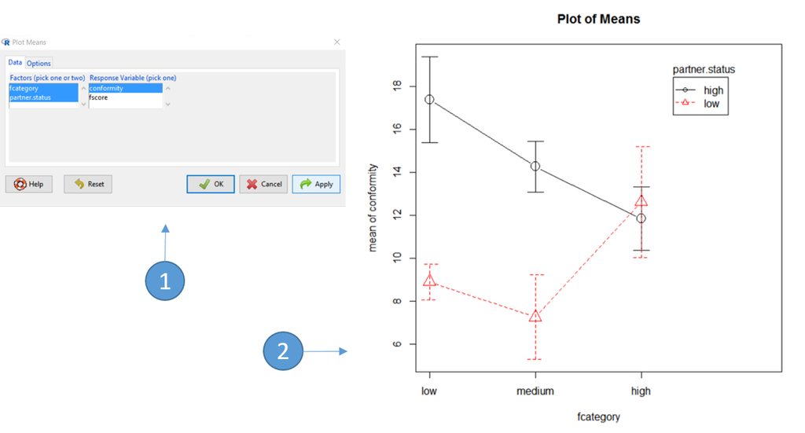

### 4.2. two-way analysis of variance

The multiway ANOVA dialog box is accessed by the `Statistics` > `Means` > `Multi-way ANOVA...` menu entry. It presents two tabs (`Data` and `Options`) shown in Figure 4.

[figure not shown]

```
> options(contrasts = c('contr.sum', 'contr.poly'))
> MooreModel.1 <- lm(conformity ~ fcategory*partner.status, data=Moore)
> .myAnova <- Anova(MooreModel.1, type = 2)
> .myAnova
Anova Table (Type II tests)
Response: conformity
                      Sum Sq Df F value   Pr(>F)
fcategory                 11.61  2  0.2770 0.759564
partner.status           212.21  1 10.1207 0.002874 **
fcategory:partner.status 175.49  2  4.1846 0.022572 *
Residuals                817.76 39
---
Signif. codes:  0 '***' 0.001 '**' 0.01 '*' 0.05 '.' 0.1 ' ' 1
```

These results indicate a significant effect of `partner.status` on the conformity, as well as an interaction between `fcategory` and `partner.status` affecting conformity, as was anticipated in this study. The use of Type III sum of squares (widely used and the default in many other statistics packages) leads to similar results.

Depending on the options chosen, supplementary output is given:

*Efffect size*

When selecting `Effect size` in the `Options` tab, partial eta squared ($\eta^2$) are computed and displayed as follows. In the present case, these values show that both the main effect and interaction effect have a large effect size according to Cohen’s guidelines:

```
>  \# EFFECT SIZE
> .effectSize <- data.frame(format(round(.myAnova$`Sum Sq` / sum(.myAnova$`Sum Sq`), 4), nsmall = 4), row.names = rownames(.myAnova))

> colnames(.effectSize) <- c("part. eta sq.")

> .effectSize
                         part. eta sq.
fcategory                       0.0095
partner.status                  0.1744
fcategory:partner.status        0.1442
Residuals                       0.6719
```

*summary statistics of groups*

When this option is selected in the `Options` tab, the mean, standard deviations and number of observations for each combination of factor levels (*cells*):

```
> \# NUMERIC SUMMARY OF GROUPS

> with(Moore, (tapply(conformity, list(fcategory, partner.status), mean, na.rm=TRUE))) # means
       high    low
low    17.40000  8.900
medium 14.27273  7.250
high   11.85714 12.625

> with(Moore, (tapply(conformity, list(fcategory, partner.status), sd, na.rm=TRUE))) # std. deviations
          high      low
low    4.505552 2.643651
medium 3.951985 3.947573
high   3.933979 7.347254

> with(Moore, (tapply(conformity, list(fcategory, partner.status), function(x) sum(!is.na(x))))) # counts
       high low
low       5  10
medium   11   4
high      7   8
```

[figure not shown]

The post-hoc analysis consist in pairwise comparison between cells using Tukey’s HSD test when interactions are significant (p < .05) or close to significant (p < 0.1) . In the present case, the interaction between the two factors is sginficant (p = 0.02, see above), which triggers the pairwise comparison:

```
> summary(glht(aov(conformity ~ fcategory.partner.status, data = Moore.extd), linfct = mcp(fcategory.partner.status = "Tukey")))

     Simultaneous Tests for General Linear Hypotheses

Multiple Comparisons of Means: Tukey Contrasts


Fit: aov(formula = conformity ~ fcategory.partner.status, data = Moore.extd)

Linear Hypotheses:
                              Estimate Std. Error t value Pr(>|t|)
medium.high - low.high == 0    -3.1273     2.4698  -1.266   0.7975
high.high - low.high == 0      -5.5429     2.6813  -2.067   0.3202
low.low - low.high == 0        -8.5000     2.5081  -3.389   0.0183 *
medium.low - low.high == 0    -10.1500     3.0718  -3.304   0.0227 *
high.low - low.high == 0       -4.7750     2.6105  -1.829   0.4543
high.high - medium.high == 0   -2.4156     2.2140  -1.091   0.8795
low.low - medium.high == 0     -5.3727     2.0008  -2.685   0.0989 .
medium.low - medium.high == 0  -7.0227     2.6736  -2.627   0.1124
high.low - medium.high == 0    -1.6477     2.1277  -0.774   0.9695
low.low - high.high == 0       -2.9571     2.2566  -1.310   0.7737
medium.low - high.high == 0    -4.6071     2.8701  -1.605   0.5950
high.low - high.high == 0       0.7679     2.3699   0.324   0.9995
medium.low - low.low == 0      -1.6500     2.7090  -0.609   0.9895
high.low - low.low == 0         3.7250     2.1721   1.715   0.5252
high.low - medium.low == 0      5.3750     2.8041   1.917   0.4024
---
Signif. codes:  0 '***' 0.001 '**' 0.01 '*' 0.05 '.' 0.1 ' ' 1
(Adjusted p values reported -- single-step method)
```

This post-hoc analysis show that the significant interaction comes from differences between low authoritarism/low status and low authoritarism/high status, as well as between medium authoritarism/low status and low authoritarism/high status. As shown in the previous plots, these two pairs of cells present indeed the largest differences of conformity.